# R Notebook

# Introduction

1. Initial state, have just had transplant
2. Platelet recovery
3. Death

It is a simple illness-death model, in that patients all start in state 1 and can transition to either 2 or 3, with there also being a platelet recovery -> death transition.

There are several covaiates available but I have just selected 2:

- ‘age’: A categorical variable with age discretised into bands
- ‘disease’: The disease that the patients are diagnosed with

# Data preparation

## Raw data

Rather than using the data set as provided by `mstate`, I’ll use a CSV I’ve written with the predictors of interest. Otherwise, there is no difference from the full data set.

```r
actual_data <- read.csv("../data/ebmt3_wide.csv")
head(actual_data)
```

```
##   id time.pr status.pr time.rfs status.rfs disease   age
## 1  1      23         1      744          0     CML   >40
## 2  2      35         1      360          1     CML   >40
## 3  3      26         1      135          1     CML   >40
## 4  4      22         1      995          0     AML 20-40
## 5  5      29         1      422          1     AML 20-40
## 6  6      38         1      119          1     ALL   >40
```

```r
sim_data <- read.csv("ebmct3_simulated_results.csv")
head(sim_data)
```

```
##   sim_num event_id   age disease Initial.time Initial.status   pr.time
## 1       1        1 20-40     ALL     11.71443              1  25.37255
## 2       1        2  <=20     AML    163.01189              1 193.26531
## 3       1        3   >40     CML    204.10384              1 223.17176
## 4       1        4 20-40     CML    204.04554              1 224.06150
## 5       1        5 20-40     AML    228.88345              1 231.50778
## 6       1        6   >40     AML    115.48629              1 244.23597
##   pr.status  rfs.time rfs.status
## 1         0  25.37255          1
## 2         1 206.84887          1
## 3         0 223.17176          1
## 4         1 227.10447          1
## 5         0 231.50778          1
## 6         0 244.23597          1
```

We can see that the simulated data set looks rather similar but has additional columns for entry into state 1. However, since our time-scale is relative to transplant, this information isn’t useful (for now), and so we should change the `pr` and `rfs` state entry times to be relative to entry into the simulation `initial.time`.

The values corresponding to entry into this initial state can then be discarded, along with the simulation number (since it was only run once).

```r
sim_data <- sim_data %>%
        mutate(pr.time = pr.time - Initial.time,
               rfs.time = rfs.time - Initial.time)  %>%
        select(-c(Initial.time, Initial.status, sim_num))
head(sim_data)
```

```
##   event_id   age disease   pr.time pr.status  rfs.time rfs.status
## 1        1 20-40     ALL  13.65811         0  13.65811          1
## 2        2  <=20     AML  30.25341         1  43.83698          1
## 3        3   >40     CML  19.06791         0  19.06791          1
## 4        4 20-40     CML  20.01595         1  23.05893          1
## 5        5 20-40     AML   2.62433         0   2.62433          1
## 6        6   >40     AML 128.74968         0 128.74968          1
```

The two data sets look the smae in terms of their structure:

```r
dim(actual_data)
```

```
## [1] 2204    7
```

```r
dim(sim_data)
```

```
## [1] 2205    7
```

I accidentally simulated one too many individuals for the DES, but this is negligible given there were over two thousand patients in total.

## Transition matrix

To compare the accuracy of the simulation, I will create multi-state models of both data sets using the non-parameteric methods provided by `mstate`. One requirement of this is a transition matrix. Fortunately, `mstate` provides illness-death transition matrices out of the box.

```r
trans_mat <- trans.illdeath()
trans_mat
```

```
##          to
## from      healthy illness death
##   healthy      NA       1     2
##   illness      NA      NA     3
##   death        NA      NA    NA
```

Where our healthy state is *Initial* (just after transplant), illness is platelet recovery (pr), and death is… well death.

## Formatting into long tables

To use `mstate`, the data needs to be in long format, with each row corresponding to a potential transition, rather than the current wide format where each row relates to an entire patient transition history. Fortunately, `mstate` provides the `msprep` function to handle this conversion.

```r
actual_long <- msprep(time=c(NA, 'time.pr', 'time.rfs'),
                      status=c(NA, 'status.pr', 'status.rfs'),
                      data=actual_data,
                      trans=trans_mat,
                      keep = c('age', 'disease'))
head(actual_long)
```

```
## An object of class 'msdata'
##
## Data:
##   id from to trans Tstart Tstop time status age disease
## 1  1    1  2     1      0    23   23      1 >40     CML
## 2  1    1  3     2      0    23   23      0 >40     CML
## 3  1    2  3     3     23   744  721      0 >40     CML
## 4  2    1  2     1      0    35   35      1 >40     CML
## 5  2    1  3     2      0    35   35      0 >40     CML
## 6  2    2  3     3     35   360  325      1 >40     CML
```

```r
sim_long <- msprep(time=c(NA, 'pr.time', 'rfs.time'),
                      status=c(NA, 'pr.status', 'rfs.status'),
                      data=sim_data,
                      trans=trans_mat,
                      keep = c('age', 'disease'))
head(sim_long)
```

```
## An object of class 'msdata'
##
## Data:
##   id from to trans   Tstart    Tstop     time status   age disease
## 1  1    1  2     1  0.00000 13.65811 13.65811      0 20-40     ALL
## 2  1    1  3     2  0.00000 13.65811 13.65811      1 20-40     ALL
## 3  2    1  2     1  0.00000 30.25341 30.25341      1  <=20     AML
## 4  2    1  3     2  0.00000 30.25341 30.25341      0  <=20     AML
## 5  2    2  3     3 30.25341 43.83698 13.58356      1  <=20     AML
## 6  3    1  2     1  0.00000 19.06791 19.06791      0   >40     CML
```

# Modelling

Before fitting Cox models to the data to determine hazard ratio estimates, I’ll look at the Kaplan-Meier estimators of each transition.

## Kaplan-Meier estimates

Firstly combine both sets of transition times into a singular data set.

```r
tot_data <- rbind(actual_long, sim_long)
tot_data$data <- rep(c('actual', 'simulated'), c(nrow(actual_long), nrow(sim_long)))
```

### Transition initial to platelet recovery

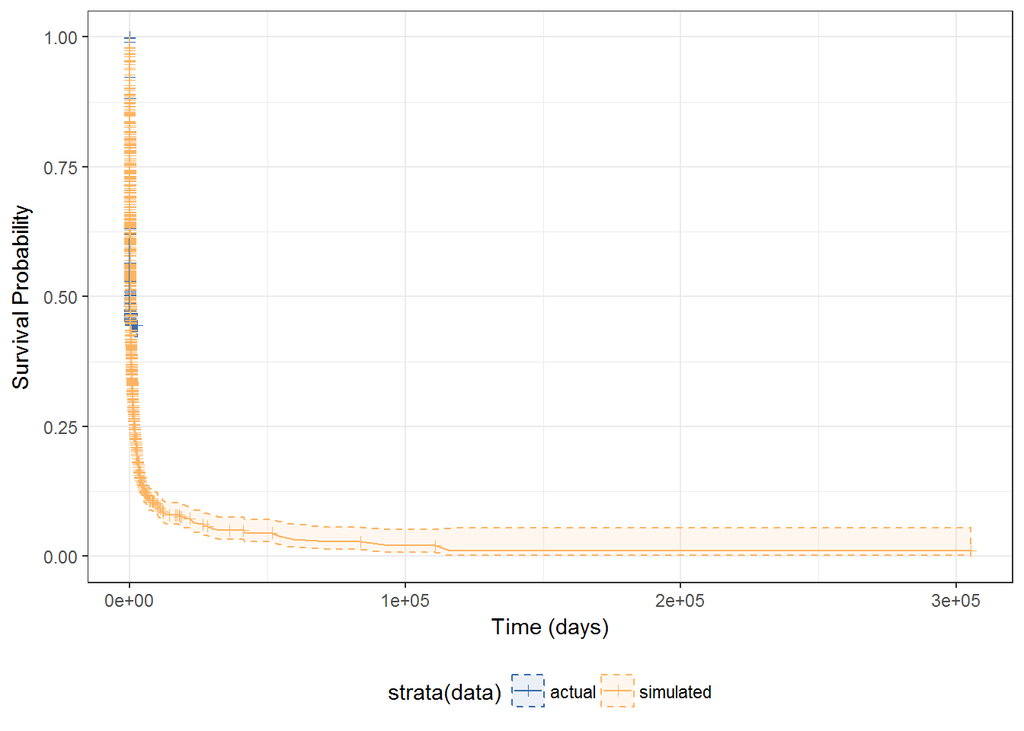

```r
ecsgR::ggkm(survfit(Surv(Tstart, Tstop, status) ~ strata(data), data=subset(tot_data, trans==1)))
```

The time-scale needs to be reduced as the simulated data set runs until patients die, which, with the use of parameteric distributions can produce ‘immortality’ resulting from drawing an extreme value from the distribution which can occur when sampling a large number of individuals. For example, in this case the maximum time to event is 3e5 days, more than 800 years.

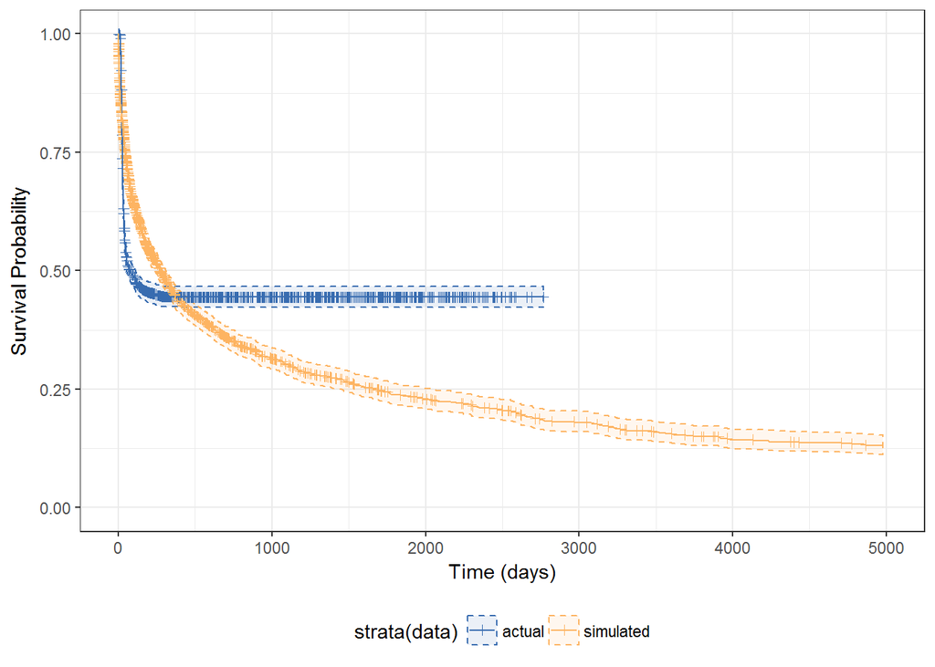

```r
ecsgR::ggkm(survfit(Surv(Tstart, Tstop, status) ~ strata(data), data=subset(tot_data, trans==1))) + xlim(0, 5e3)
```

This shows that the underlying time-to-event distributions are rather different. This could be influenced by the fact that the simulated patients are followed up until they die, which due to the afore-mentioned ‘immortality’ issue can skew the results.

### Transition initial to death

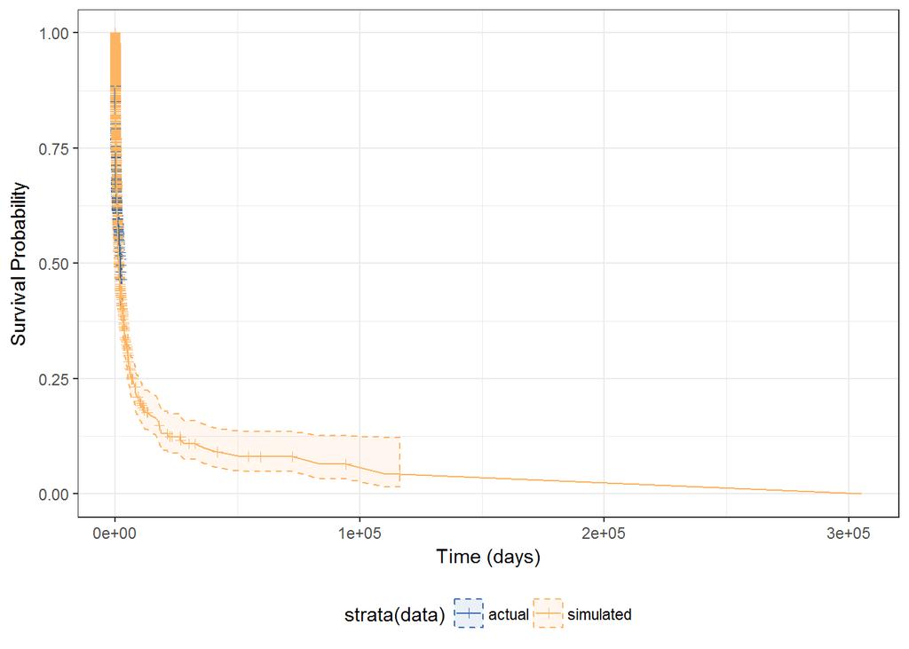

```r
ecsgR::ggkm(survfit(Surv(Tstart, Tstop, status) ~ strata(data), data=subset(tot_data, trans==2)))
```

Again, the x-axis needs to be truncated to better observe the models.

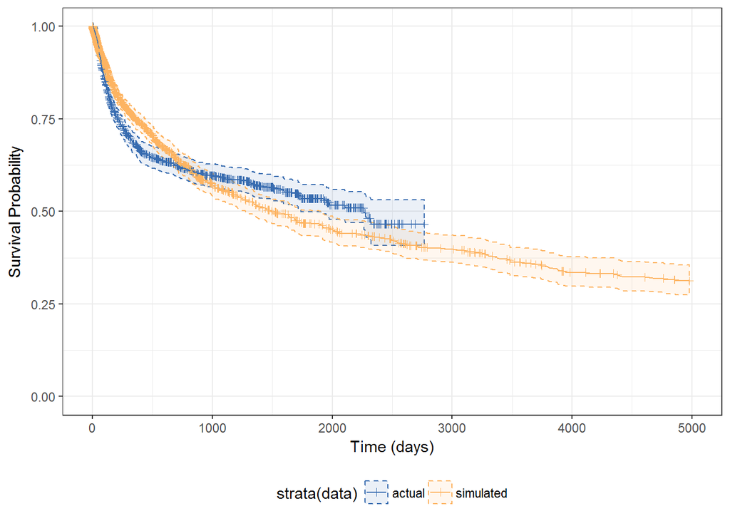

```r
ecsgR::ggkm(survfit(Surv(Tstart, Tstop, status) ~ strata(data), data=subset(tot_data, trans==2))) + xlim(0, 5e3)
```

This model looks a better fi, with the simulated data following a similar trajectory to the observed.

### Platelet recovery to death

Another rescaling is required here:

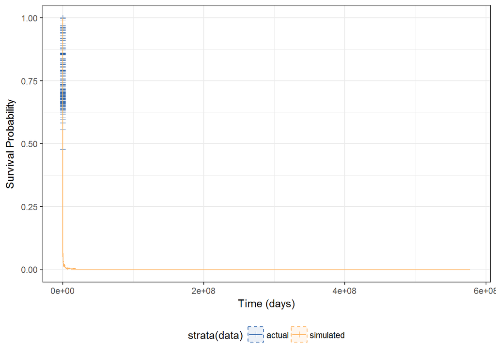

```r
ecsgR::ggkm(survfit(Surv(Tstart, Tstop, status) ~ strata(data), data=subset(tot_data, trans==3)))
```

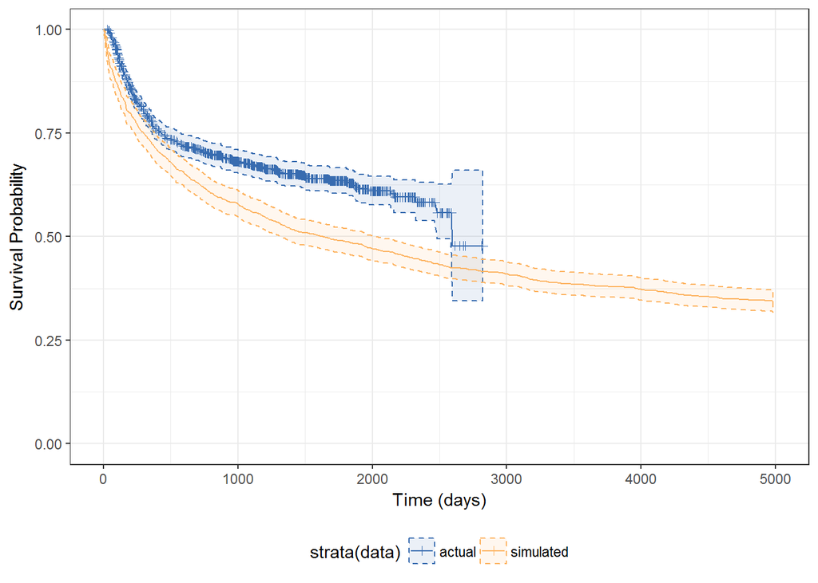

```r
ecsgR::ggkm(survfit(Surv(Tstart, Tstop, status) ~ strata(data), data=subset(tot_data, trans==3))) + xlim(0, 5e3)
```

Again, this model looks a better fit than the initial -> platelet recovery one.

## Model comparison

The actual modelling is carried out by the standard Cox PH estimator from the `survival` package and can be facilitated now that the data is correctly formatted. For both data sets I’ll make the same assumptions:

1. The process is a Markov model, i.e. all information regarding a process’ history can be summarised by its current state
2. Each transition has a different baseline hazard

```r
coxph(Surv(Tstart, Tstop, status) ~ age + disease + strata(trans), data=actual_long)
```

```
## Call:
## coxph(formula = Surv(Tstart, Tstop, status) ~ age + disease +
##     strata(trans), data = actual_long)
##
##                coef exp(coef) se(coef)     z      p
## age>40      0.21248   1.23674  0.06704  3.17 0.0015
## age20-40   -0.00594   0.99407  0.06289 -0.09 0.9247
## diseaseAML -0.05366   0.94775  0.06137 -0.87 0.3820
## diseaseCML -0.18889   0.82787  0.06323 -2.99 0.0028
##
## Likelihood ratio test=26.8  on 4 df, p=2.15e-05
## n= 5577, number of events= 2010
```

```r
coxph(Surv(Tstart, Tstop, status) ~ age + disease + strata(trans), data=sim_long)
```

```
## Call:
## coxph(formula = Surv(Tstart, Tstop, status) ~ age + disease +
##     strata(trans), data = sim_long)
##
##               coef exp(coef) se(coef)     z       p
## age>40      0.2274    1.2554   0.0469  4.85 1.3e-06
## age20-40    0.0578    1.0596   0.0432  1.34   0.181
## diseaseAML -0.0475    0.9536   0.0453 -1.05   0.295
## diseaseCML -0.1031    0.9020   0.0453 -2.28   0.023
##
## Likelihood ratio test=35  on 4 df, p=4.68e-07
## n= 5941, number of events= 3736
```

The hazard ratios are very similar for both models, with the p-values indicating the same variables are statistically significant, even if the actual coefficients differ. For example, `age20-40` is deemed to have a negative impact on hazard on the real data set, while the effect is slightly positive in the simulated data set. However, in both cases, the p-value is not significant.

These results suggest that the DES is able to accurately model the real data set. More evidence, however, would be useful for further validation.